# Coursera Course - Reproducible Research - Storm Data Analysis

Teddy Rusli

Thursday, April 26, 2015

# Synopsis

This project involves exploring the U.S. National Oceanic and Atmospheric Administration’s (NOAA) storm database. This database tracks characteristics of major storms and weather events in the United States, including when and where they occur, as well as estimates of any fatalities, injuries, and property damage.

This analysis finds that Tornado is the most harmful severe weather in affecting population health. Excessive Heat is second when it comes to fatalities. TSTM wind is second when it comes to injuries.

With regards to property damage, Tornado is again the most harmful. Hail is, however, the most damaging to crops.

### Data Processing

[output not shown]

There is some documentation of the database available. Here you will find how some of the variables are constructed/defined. - National Weather Service [Storm Data Documentation](https://d396qusza40orc.cloudfront.net/repdata%2Fpeer2_doc%2Fpd01016005curr.pdf) - National Climatic Data Center Storm Events [FAQ](https://d396qusza40orc.cloudfront.net/repdata%2Fpeer2_doc%2FNCDC%20Storm%20Events-FAQ%20Page.pdf) The events in the database start in the year 1950 and end in November 2011. In the earlier years of the database there are generally fewer events recorded, most likely due to a lack of good records. More recent years should be considered more complete.

Step 1: Download and uncompress bzip2 data file

```r
echo = TRUE  # Show R code
setwd("~/GitHub/RepData_PeerAssessment2")
setInternet2(TRUE)
download.file("https://d396qusza40orc.cloudfront.net/repdata%2Fdata%2FStormData.csv.bz2",
              destfile = "stormData.csv.bz2")
bunzip2("stormData.csv.bz2", overwrite=T, remove=F)
```

Step 2: Describe the data set

```r
stormDF<- read.csv("stormData.csv")
str(stormDF)
```

```
## 'data.frame':    902297 obs. of  37 variables:
##  $ STATE__   : num  1 1 1 1 1 1 1 1 1 1 ...
##  $ BGN_DATE  : Factor w/ 16335 levels "1/1/1966 0:00:00",..: 6523 6523 4242 11116 2224 2224 2260 383 3980 3980 ...
##  $ BGN_TIME  : Factor w/ 3608 levels "00:00:00 AM",..: 272 287 2705 1683 2584 3186 242 1683 3186 3186 ...
##  $ TIME_ZONE : Factor w/ 22 levels "ADT","AKS","AST",..: 7 7 7 7 7 7 7 7 7 7 ...
##  $ COUNTY    : num  97 3 57 89 43 77 9 123 125 57 ...
##  $ COUNTYNAME: Factor w/ 29601 levels "","5NM E OF MACKINAC BRIDGE TO PRESQUE ISLE LT MI",..: 13513 1873 4598 10592 4372 10094 1973 23873 24418 4598 ...
##  $ STATE     : Factor w/ 72 levels "AK","AL","AM",..: 2 2 2 2 2 2 2 2 2 2 ...
##  $ EVTYPE    : Factor w/ 985 levels "   HIGH SURF ADVISORY",..: 834 834 834 834 834 834 834 834 834 834 ...
##  $ BGN_RANGE : num  0 0 0 0 0 0 0 0 0 0 ...
##  $ BGN_AZI   : Factor w/ 35 levels "","  N"," NW",..: 1 1 1 1 1 1 1 1 1 1 ...
##  $ BGN_LOCATI: Factor w/ 54429 levels "","- 1 N Albion",..: 1 1 1 1 1 1 1 1 1 1 ...
##  $ END_DATE  : Factor w/ 6663 levels "","1/1/1993 0:00:00",..: 1 1 1 1 1 1 1 1 1 1 ...
##  $ END_TIME  : Factor w/ 3647 levels ""," 0900CST",..: 1 1 1 1 1 1 1 1 1 1 ...
##  $ COUNTY_END: num  0 0 0 0 0 0 0 0 0 0 ...
```

[output cut: 23 more lines]

```r
head(stormDF)
```

```
##   STATE__           BGN_DATE BGN_TIME TIME_ZONE COUNTY COUNTYNAME STATE
## 1       1  4/18/1950 0:00:00     0130       CST     97     MOBILE    AL
## 2       1  4/18/1950 0:00:00     0145       CST      3    BALDWIN    AL
## 3       1  2/20/1951 0:00:00     1600       CST     57    FAYETTE    AL
## 4       1   6/8/1951 0:00:00     0900       CST     89    MADISON    AL
## 5       1 11/15/1951 0:00:00     1500       CST     43    CULLMAN    AL
## 6       1 11/15/1951 0:00:00     2000       CST     77 LAUDERDALE    AL
##    EVTYPE BGN_RANGE BGN_AZI BGN_LOCATI END_DATE END_TIME COUNTY_END
## 1 TORNADO         0                                               0
## 2 TORNADO         0                                               0
## 3 TORNADO         0                                               0
## 4 TORNADO         0                                               0
## 5 TORNADO         0                                               0
## 6 TORNADO         0                                               0
##   COUNTYENDN END_RANGE END_AZI END_LOCATI LENGTH WIDTH F MAG FATALITIES
```

[output cut: 20 more lines]

```r
dim(stormDF)
```

```
## [1] 902297     37
```

Step 3: Across the United States, which types of events (as indicated in the EVTYPE variable) are most harmful with respect to population health?

```r
fatalities <- aggregate(stormDF[, 'FATALITIES'],FUN = sum,by = list(stormDF$EVTYPE))
names(fatalities)[1]<-paste("Fatalities")
names(fatalities)[2]<-paste("Frequency")
fatalitiesTop <- subset(fatalities, Frequency > 0)
fatalitiesTop <- arrange(fatalitiesTop, fatalitiesTop[,2], decreasing = T)

injuries <- aggregate(stormDF[, 'INJURIES'],FUN = sum,by = list(stormDF$EVTYPE))
names(injuries)[1]<-paste("Injuries")
names(injuries)[2]<-paste("Frequency")
injuriesTop <- subset(injuries, Frequency > 0)
injuriesTop <- arrange(injuriesTop, injuriesTop[,2], decreasing = T)
```

Step 4: Across the United States, which types of events have the greatest economic consequences?

```r
propDamage <- aggregate(stormDF[, 'PROPDMG'],FUN = sum,by = list(stormDF$EVTYPE))
names(propDamage)[1]<-paste("PropertyDamageType")
names(propDamage)[2]<-paste("Amount")
propDamageTop <- subset(propDamage, Amount > 0)
propDamageTop <- arrange(propDamageTop, propDamageTop[,2], decreasing = T)

cropDamage <- aggregate(stormDF[, 'CROPDMG'],FUN = sum,by = list(stormDF$EVTYPE))
names(cropDamage)[1]<-paste("CropDamageType")
names(cropDamage)[2]<-paste("Amount")
cropDamageTop <- subset(cropDamage, Amount > 0)
cropDamageTop <- arrange(cropDamageTop, cropDamageTop[,2], decreasing = T)
```

### Results

The most harmful fatalies are Tornado and Excessive Heat.

```r
head(fatalitiesTop,10)
```

```
##        Fatalities Frequency
## 1         TORNADO      5633
## 2  EXCESSIVE HEAT      1903
## 3     FLASH FLOOD       978
## 4            HEAT       937
## 5       LIGHTNING       816
## 6       TSTM WIND       504
## 7           FLOOD       470
## 8     RIP CURRENT       368
## 9       HIGH WIND       248
## 10      AVALANCHE       224
```

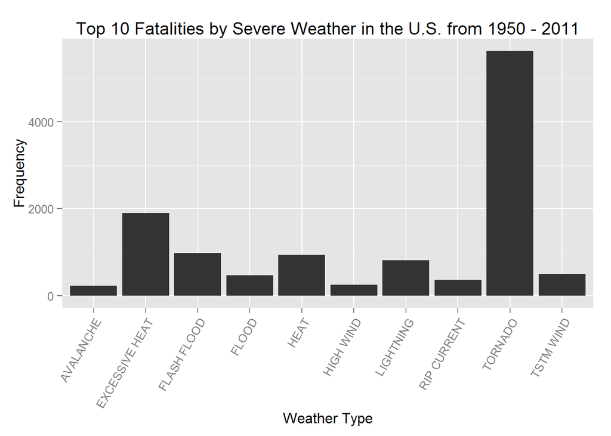

```r
qplot(Fatalities, data = head(fatalitiesTop,10), weight = Frequency, geom = "bar", binwidth = 1) +
    ggtitle("Top 10 Fatalities by Severe Weather in the U.S. from 1950 - 2011") +
    xlab("Weather Type") +
    theme(axis.text.x = element_text(angle = 60, hjust = 1)) +
    scale_y_continuous("Frequency")
```

The most harmful injuries are Tornado and TSTM Wind. It is worth noting that Tornado fequency are more than 10 times TSTM Winds’s

```r
head(injuriesTop,10)
```

```
##             Injuries Frequency
## 1            TORNADO     91346
## 2          TSTM WIND      6957
## 3              FLOOD      6789
## 4     EXCESSIVE HEAT      6525
## 5          LIGHTNING      5230
## 6               HEAT      2100
## 7          ICE STORM      1975
## 8        FLASH FLOOD      1777
## 9  THUNDERSTORM WIND      1488
## 10              HAIL      1361
```

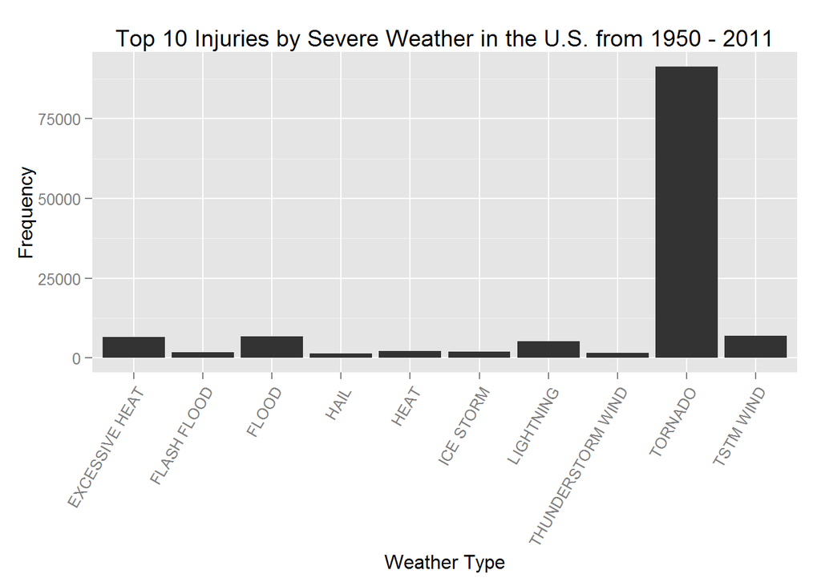

```r
qplot(Injuries, data = head(injuriesTop,10), weight = Frequency, geom = "bar", binwidth = 1) +
    ggtitle("Top 10 Injuries by Severe Weather in the U.S. from 1950 - 2011") +
    xlab("Weather Type") +
    theme(axis.text.x = element_text(angle = 60, hjust = 1)) +
    scale_y_continuous("Frequency")
```

The most property damaging are Tornado and Flash Flood.

```r
head(propDamageTop,10)
```

```
##    PropertyDamageType    Amount
## 1             TORNADO 3212258.2
## 2         FLASH FLOOD 1420124.6
## 3           TSTM WIND 1335965.6
## 4               FLOOD  899938.5
## 5   THUNDERSTORM WIND  876844.2
## 6                HAIL  688693.4
## 7           LIGHTNING  603351.8
## 8  THUNDERSTORM WINDS  446293.2
## 9           HIGH WIND  324731.6
## 10       WINTER STORM  132720.6
```

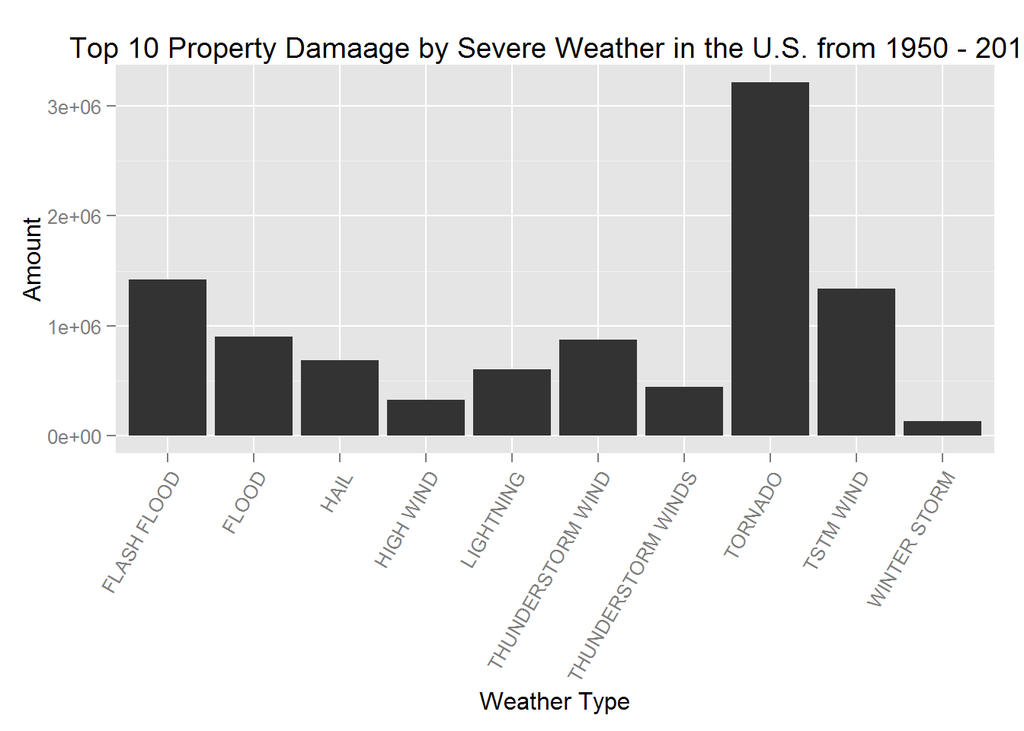

```r
qplot(PropertyDamageType, data = head(propDamageTop,10), weight = Amount, geom = "bar", binwidth = 1) +
    ggtitle("Top 10 Property Damaage by Severe Weather in the U.S. from 1950 - 2011") +
    xlab("Weather Type") +
    theme(axis.text.x = element_text(angle = 60, hjust = 1)) +
    scale_y_continuous("Amount")
```

The most crop damaging are Hail and Flash Flood.

```r
head(cropDamageTop,10)
```

```
##        CropDamageType    Amount
## 1                HAIL 579596.28
## 2         FLASH FLOOD 179200.46
## 3               FLOOD 168037.88
## 4           TSTM WIND 109202.60
## 5             TORNADO 100018.52
## 6   THUNDERSTORM WIND  66791.45
## 7             DROUGHT  33898.62
## 8  THUNDERSTORM WINDS  18684.93
## 9           HIGH WIND  17283.21
## 10         HEAVY RAIN  11122.80
```

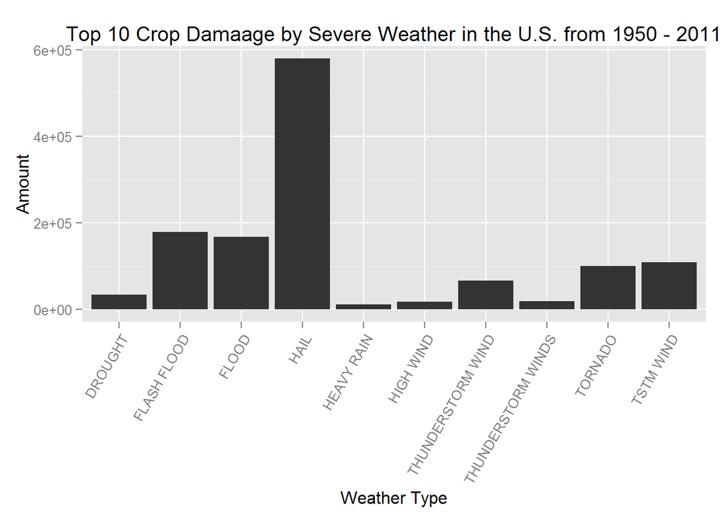

```r
qplot(CropDamageType, data = head(cropDamageTop,10), weight = Amount, geom = "bar", binwidth = 1) +
    ggtitle("Top 10 Crop Damaage by Severe Weather in the U.S. from 1950 - 2011") +
    xlab("Weather Type") +
    theme(axis.text.x = element_text(angle = 60, hjust = 1)) +
    scale_y_continuous("Amount")
```